# Sensors and Sunlight: How We Can Identify Plant Species Without Seeing Them

## Background

### How is identifying plants without seeing them even possible?

The type of light that we as humans can see is called visible light, and this light is what brings color to our world. It's what makes the ocean look blue or the grass green. Everything on Earth absorbs and reflects light, including plants, but the amount that is absorbed and reflected varies from object to object. Plants, for example, are green because the majority of the light they reflect is green light. They reflect lights in other colors as well, but they mostly absorb them. However, all plants are different. Let's say the light that plant A is reflecting is 95% green light and 5% blue light, whereas plant B is reflecting 85% green light and 15% blue light. Specialized field equipment can be used to determine what type of light a plant is reflecting and how much of it. Similarly, these measurements can be made on a larger scale by flying sensors that also measure how much of each light type is reflected over the Earth's surface, and we can make determinations of what plant species are where by combining these data. This is the end-goal of the project on which I'm working using data obtained by the National Ecological Observatory Network (NEON), and my part is to create a reproducible analysis to start working toward that goal.

### Where is NEON data collected?

NEON data is collected at 81 sites located throughout the United States (shown in the first image below), but my analysis is being created with the sites in the western United States in mind (shown in the second image below). However, the analysis can be used for any NEON site where plants grow.

```
[Text(0.5, 24.0, 'Latitude'),
```

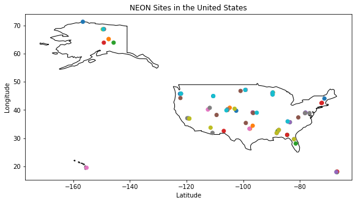

*Locations of NEON field sites.*

```
(25.0, 50.0)
```

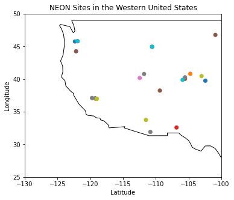

*Extent of the project study area and the NEON sites within it.*

## Data Application

### How exactly will your analysis help identify plants?

The reproducible analysis that I am working on for my project will allow users to select NEON sites of interest by filtering NEON sites by site characteristics and location. The extent of the project area is the western United States; however any four coordinates can be used to form a polygon that will return the NEON sites located within it. Further, users can filter by site characteristics such as if non-neon research is allowed, average number of green days per year, soil type, field site type (e.g. terrestrial or aquatic), along with other characteristics. Once sites of interest are known, the analysis will also report the dates when reflectance data was collected and is available for the filtered sites, request the reflectance data, process the reflectance data, and plot the reflectance data. Plotting the data and being able to visualize it will allow researchers to make decisions regarding when sampling should take place.

### What does reflectance data look like?

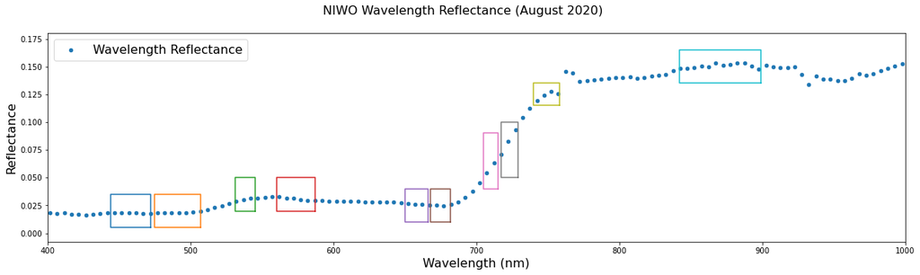

*All wavelengths represented in a single reflectance file. Boxes represent groups of bands that the project aims to analyze.*

```
band 38 center wavelength (nm):  566.9639
```

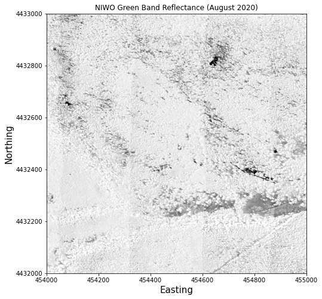

*Green reflectance band visualization.*

## Current Findings and Future Work

### So what did you find?

So far, I've discovered how to create most parts of the analysis and have begun to put them together in a way that ensures it is reproducible.

### How did you do this?

Individual parts will allow users to do the following:

1. Select NEON sites of interest by filtering sites by site characteristics and location.
2. Report the dates when data was collected and is available for the filtered sites.
3. Request the data.
4. Prepare the data for plotting.
5. Plot the data.

Currently, I have combined steps 1-3 so that all sites that make it past filtering are reported along with the dates that have available data; and along with each date, a list of data files is reported, each one containing data that can be analyzed by the reproducible analysis.

### Why does it matter?

This workflow is simplifying the analysis by combining multiple steps that, if done individually, would be time-consuming and inefficient. This reproducible analysis is also the project's preliminary work, so it is laying the groundwork for future steps taken toward the project's end-goal.

### What's next?

I will finish combining the parts of the analysis that will prepare the data for plotting and plot the data. Beyond the creation of this analysis, future work will involve analyzing the plotted data between different spatial and temporal points to determine when and where sampling should be conducted to capture as much data as possible.

## Resources

### Additional Information

Visit https://github.com/rami8797/macrosystems_spectral_variance for more information regarding this project.

### Citations

Data used to produce figures was made available by the National Ecological Observatory Network (NEON).